# How to use Well Plate Maker

Helene Borges

6 mai 2020

#### Abstract

WPM is a shiny application deployed in the form of an R package. Its objective is to allow the user to create one (or more) plate plans in order to perform his experiments by controlling **batch effects** (in particular preventing plate edge effects) without programming skills.

# 1 Introduction

The `wpm` package contains one unique function for the user that runs a shiny application. The user does not need to write an R command line or have any programming skills.

To generate plate plans, WPM uses an algorithm inspired from the backtracking algorithm. In other words, WPM will gradually fill the plate by randomly traversing it. At each well chosen (randomly), WPM will randomly choose a sample which satisfies all the constraints specified during the configuration step.

# 2 Getting started

## 2.1 Prerequisites

This tutorial explains how to use the Well Plate Maker shiny application. Make sure you are using the R 4.0.0 version. Also, check that you have these packages installed (with their dependencies): *shiny*, *shinydashboard*, *shinyWidgets* , *shinycustomloader*, *DT*, *RColorBrewer*, *logging*, *dplyr*, *stringr*, *ggplot2*

## 2.2 Installation

From **BioConductor**:

```r
if (!requireNamespace("BiocManager", quietly = TRUE))
    install.packages("BiocManager")

BiocManager::install("wpm")
```

## 2.3 Launch WPM

Whether you use RStudio or simply work with an R console, the procedure remains the same:

```r
library(wpm)
wpm()
```

If everything is in order, a new window will open in your default browser. If not, find a line written in the R console (eg. `Listening on http://127.0.0.1:4028`), and paste the URL in your web browser.

# 3 How to use WPM

Since WPM is a GUI, the idea is to just provide a minimum of parameters to the application. No programming skills are required. WPM supports multiple plates and places samples in a balanced way among the plates.

WPM has 4 main panels: **Home**, **Parameters**, **Results** and **Help**.

## 3.1 The **Home** Panel

This page briefly presents the aim of the app, shows the last package version and explains how to cite us to support our work.

[figure not shown]

The Home page when wpm is started

## 3.2 The **Parameters** Panel

Overall the page is organized in two sections. The one on the left contains all the configuration steps. The one on the right summarizes the parameters entered as well as the plate plan which will be used by WPM. The right section is automatically updated each time a parameter is changed in the left section.

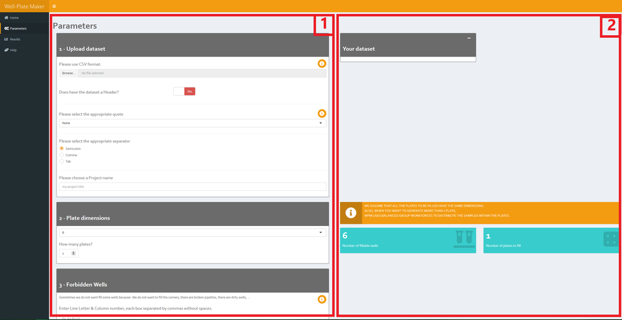

Parameters Panel

The section 1 is divided into 6 main steps, detailed below. This part is the most important to understand and master because it is here that we will specify all the constraints for generating the desired plate planes.

### 3.2.1 Upload dataset

Here you must provide a **CSV** file containing at least one kind of information: the sample names.

| Sample |
| --- |
| s1 |
| s2 |
| s3 |
| s4 |

If your samples belong to different groups that you want to distinguish, then you must provide the additional column “Group”.

| Sample | Group |
| --- | --- |
| s1 | A |
| s2 | A |
| s3 | B |
| s4 | C |

**IMPORTANT** Please respect this ORDER of columns for the data in the CSV file: [Sample, Group]

The names you give to columns do not matter, because WPM will change them into *“Sample”* and *“Group”*.

After uploading the CSV file, these 3 next sub-steps are important:

- check if your file does have a **header**.
- select the right type of **quotes**. Default is none, meaning that there is no *"* or *’* characters in your file.
- select the appropriate **separator** field. Default is semicolon (*“;”*)

You will see your dataset on the right side of the window, with a new column added: “ID”. Each sample is assigned a unique ID, which will be used to assign the samples to plate plans (for more details on the ID see the Results section ).

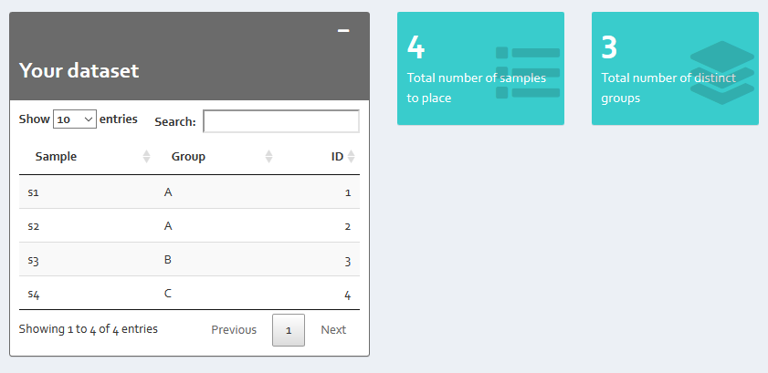

Dataset vizualisation

**IMPORTANT** Be careful and please ensure that the dataset is correctly displayed in the right window and that the number of samples / groups is correct. If you see that the total number of samples is wrong, this means that you have not chosen the appropriate options among those described above and you need to set the correct ones.

The last sub-step *Choose a Project name* is optionnal. If you provide one, it will be used in the plots titles and in the name of the final dataset.

### 3.2.2 Plate(s) dimensions

Here you have to specify the plate dimensions and their number. Currently, WPM supports plate dimensions of 6,24, 48, 96, 386, 1534 wells and a custom option (where you specify the number of lines and columns by hand).

To the right of step 2 you can see an information box, warning you that WPM will distribute the samples in a balanced manner within the plates (if there are several).

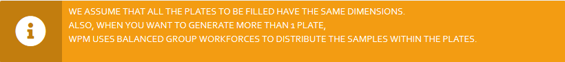

balanced way message

If you select a plate size compatible with the total number of samples, you will see two blues boxes and a plate plan appear on the right summarizing all of your configuration. In the example below, we selected the pre-defined dimension of 96 wells and only one plate:

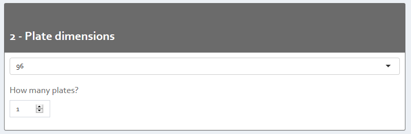

plate dimensions example

The right side of the panel will summarize all these parameters:

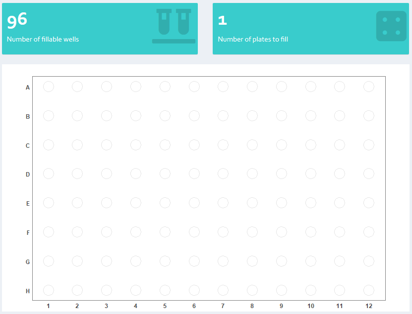

parameters summary

This plot updates with each modification of the parameters, thus making it possible to see if one has made an error.

**IMPORTANT**: If WPM detects a problem or incompatibility between parameters, you will see an error message instead of the plate plan, explaining you what could be the problem.

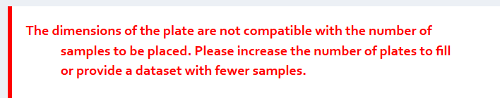

Example of error message

### 3.2.3 Forbidden wells

In this step are listed the **Forbidden wells** if any (this is optionnal of course):

> A **Forbidden well** will not be filled with any kind of sample. We simply do not want to fill them (*e.g.* the coins of the plate), or in case of dirty wells, broken pipettes, etc.

You fill the text input with a combination of letters and numbers like in the example below:

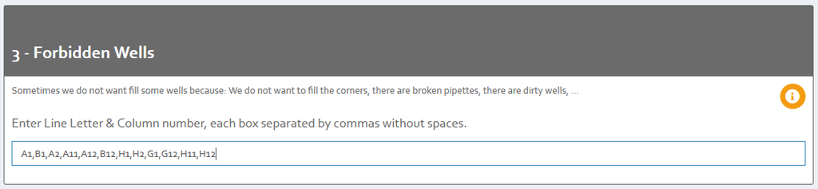

Example of forbidden wells listed in the text input

You will see the plot updated in the right section:

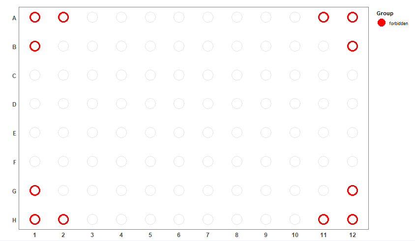

Updated plot with forbidden wells

The wells filled with forbidden wells will have the *“forbidden”* ID in the final dataset.

### 3.2.4 Blanks

At this stage you can specify the wells which correspond to blanks, if there are any.

> A **Blank well** corresponds to wells filled in with solution but without biological material (*e.g.* to avoid cross-contamination).

Five modes are available for placing the blanks:

**1)** *no blanks*: there will be no blank on the plate(s).

**2)** *Per line*: Automatically places blanks every other line. You can choose to start placing in even or odd line.

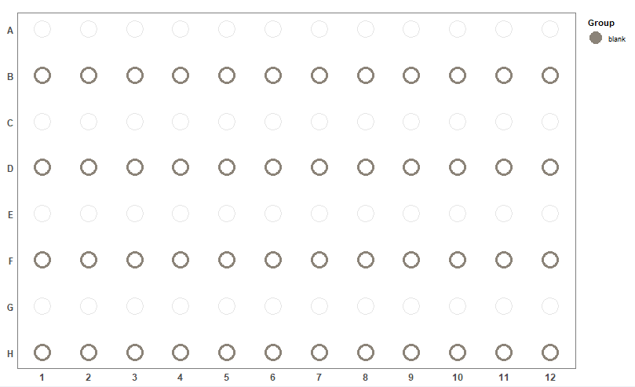

Per line mode example with even option

**3)** *Per column*: Automatically places blanks every other column. You can choose to start placing in even or odd column.

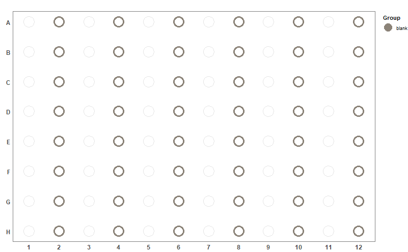

Per Column mode example with even option

**4)** *Checkerboard*: Automatically places blanks like a checkerboard.

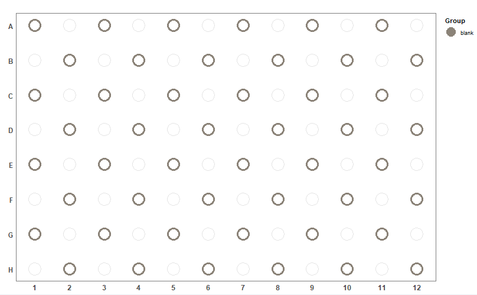

Checkerboard mode

**5)** *Choose by hand*: It is the same procedure as for specifying forbidden wells.

**Specify the neighborhood constraints**

These are the spatial constraints that WPM needs to create the plates. Currently, there are 4 types proposed. Note that the modes are available only if they are compatible with the chosen blank mode. The question here is: Should samples from the same group be found side by side?

Schematically, the spatial constraints can be summarized as follows (the blue well is the current well evaluated by WPM; The wells in green are those assessed for compliance with the chosen constraint. The blue well therefore has the possibility (but not the obligation since the filling of the plate is done randomly) to be filled with a sample belonging to the same group as the samples in the wells evaluated.

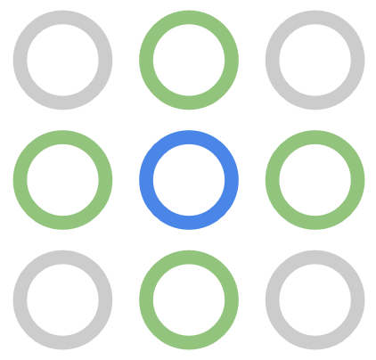

No constraint

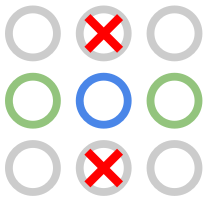

North-South constraint

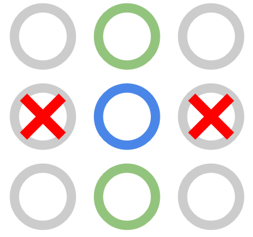

East-West constraint

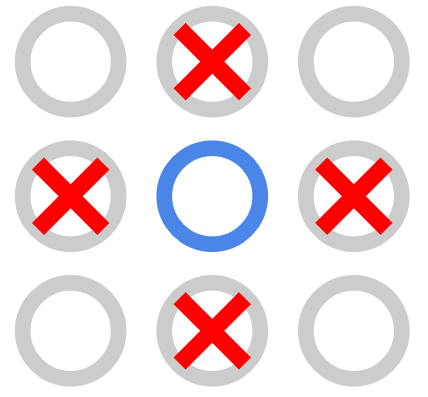

North-South-East-West constraint

The wells filled with blank wells will have the *“blank”* ID in the final dataset.

### 3.2.5 Not Randomized wells

At this stage you can specify the wells which correspond to not randomized wells, if there are any.

> A **Not Randomized well** corresponds to quality control samples or standards, the precise location of which must be controlled by the experimenter.

This step works in exactly the same way as the forbidden well step. The only difference is that the not randomized will appear in **black** on the plot.

The wells filled with not randomized wells will have the *“notRandom”* ID in the final dataset.

### 3.2.6 Number of iterations

Here you choose a maximum number of iterations that WPM can do to find a solution, then start WPM by clincking the **“start WPM”** button. The default value is 20, but if your configuration is somewhat complex, then it is advisable to increase this number. An *iteration* corresponds to an attempt by WPM to find a solution. The algorithm used is not a “full” backtracking: WPM stops as soon as there are no more possibilities to finalize the current solution, and starts from scratch the plate plan, until providing a solution that complements all the constraints. With this approach, not all possible combinations are explored, but it does reduce execution time. A more “complete” version of backtracking could possibly be an improvement to bring in the future.

When you start WPM, a progress bar shows which iteration WPM is at.

If WPM finds a solution, you will see this pop in the browser, inviting you to go to the Result Panel:

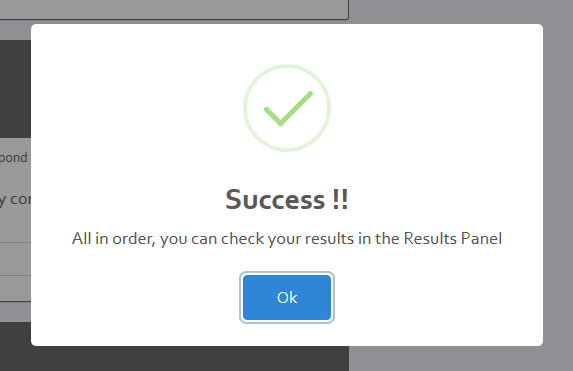

WPM succeeded

If WPM fails, an error message will appear, prompting you to try again:

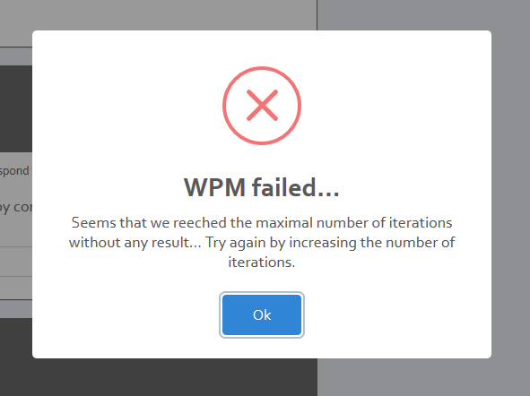

WPM failed

**IMPORTANT** We recommend to refresh the web session by using `Ctrl + F5` before changing the parameters. It will completely restart the parameters panel but will avoid a known issue, we are currently trying to fix.

## 3.3 The **Results** Panel

This Panel allows you to look after the final dataset containing the wells chosen for each sample:

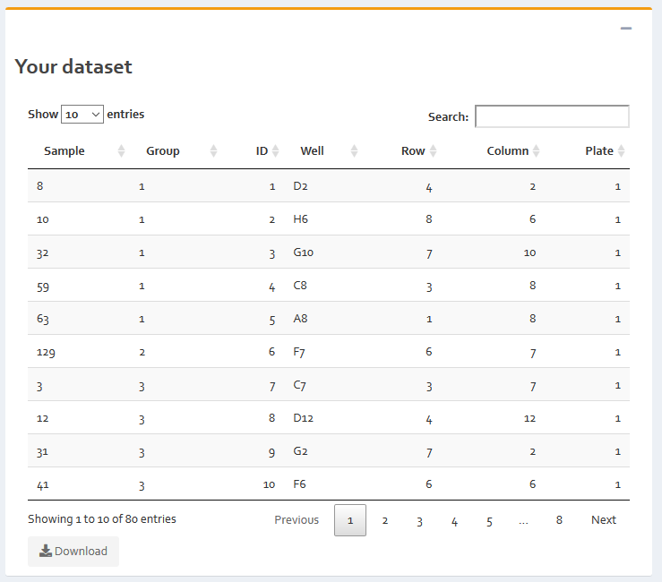

Final dataframe

The dataframe contains 7 columns giving all the information needed to run the experiment: The sample name with its corresponding group; its ID for the plot; the well chosen; the row and the column to which the well corresponds and the number of the plate on which the sample must be placed during the experiment.

This Panel also shows you the generated plot(s) of your final well-plate map(s). One color corresponds to one group level. The numbers are the IDs used in place of the sample names which could be too long and make the plot unreadable.

Below is an example of 80 samples distributed in 10 groups and placed on a 96 well-plate, with the North-South-East-West neighborhood constraint:

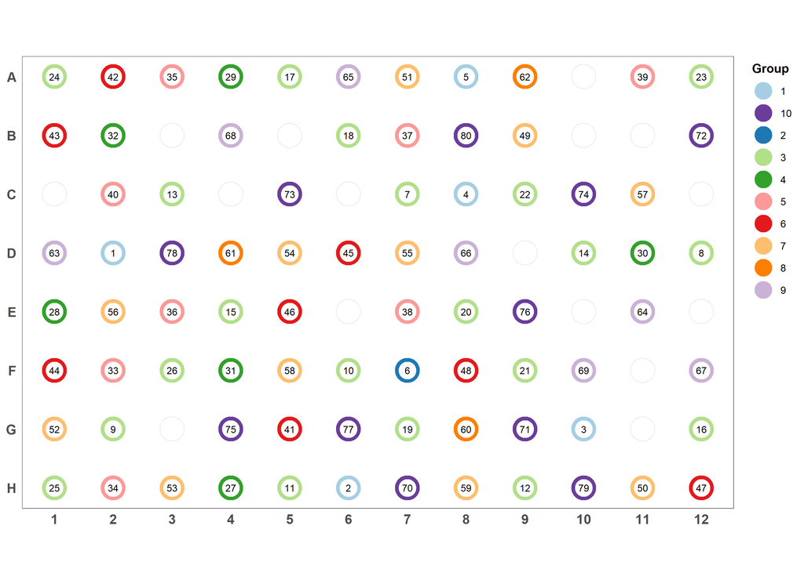

Plate map

Dataframe and plots are downloadable separately.

## 3.4 The **Help** Panel

In this panel you will find the email of contact, how to open a new issue for the project and how to find this vignette.

# 4 Citing Our work